# Project 2

Which factors influence a student’s grade?

510603294, 520438936, 510513719, 520450156, 520512915

University of Sydney | 2022-04-14

## Executive Summary

The purpose of this report is to look into the elements that influence students’ grades.  
- The major findings were that students who *study longer* and *sleep 6~8 hours a day* are more likely to have a better ATAR score as well as satisfactory university academic achievement.  
- Furthermore, it appears that a student’s typical working hours and caffeine consumption are inversely proportional to their school performance.  
- Finally, it appeared that public high school students had the widest range of ATAR scores and the lowest median score.

## Initial Data Analysis (IDA)

- **source:** Acquired from survey responses using volunteer selection
- **sample:** Consisting primarily of USYD students.
- **variables** 4 Qualitative (2 ordinal, 2 nominal), 6 Quantitative (All Discrete)
- **limitation**: Data is based on self report, meaning that there are likely inaccuracies in quantifying hours of study, sleep etc. The assumption is made that the quantity reported by respondents is approximately accurate. It is also assumed that for questions with a more ‘objective’ type of answer, such as ATAR or type of school, the responses are honest and accurate.
- **Data Wrangling**: For questions that required a quantitative response (such as number of hours or cups), any response containing a number and a word was cleaned to remove the word and record the number only. Data from respondents who gave consistently facetious responses was removed, as well as one response that did not provide their ATAR.

Size of Data (# of reponses) = 30

| Gender | ATAR | Study/week | Sleep/day | Work/week | High School | Academic Performance (self-rated) | Physical Activity/week | Tutoring/week (high school) | Caffeine Consumption/week |
| --- | --- | --- | --- | --- | --- | --- | --- | --- | --- |
| (Qualitative) | (Quantitative) | (Quantitative) | (Qualitative) | (Quantitative) | (Qualitative) | (Qualitative) | (Quantitative) | (Quantitative) | (Quantitative) |
| Male = 16 | Mean = 94.29 | Mean = 20.08 hr. | 4~6 hr. = 3 | Mean = 7.8 hr. | Public= 10 | 1~4= 6 | Mean = 5.47 hr. | Mean = 4.3 hr. | Mean = 3.03 cups |
| Female = 12 | Median = 96.5 | Median = 18 hr. | 6~8 hr. = 20 | Median = 8.5 hr. | Private= 10 | 5~7= 12 | Median = 5 hr. | Median = 4 hr. | Median = 2 cups |
| Not Replied = 2 |  |  | 8~10 hr. = 7 |  | Selective= 10 | 8~10= 12 |  |  |  |
|  |  |  |  |  |  | Mean = 6.63 |  |  |  |

```r
surv_data$Gender <- factor(surv_data$Gender,
    levels=c("Male", "Female", "Choose not to specify."))

surv_data$Sleep <- factor(surv_data$Sleep,
    levels=c("4 to 6 hours", "6 to 8 hours", "8 to 10 hours"))

surv_data$`High School` <- factor(surv_data$`High School`,
    levels=c("Public", "Private", "Selective"))

str(surv_data)
```

```
## tibble [30 x 11] (S3: tbl_df/tbl/data.frame)
##  $ Timestamp           : POSIXct[1:30], format: "2022-03-31 16:53:43" "2022-03-31 16:54:10" ...
##  $ Gender              : Factor w/ 3 levels "Male","Female",..: 1 2 1 1 1 3 1 2 1 1 ...
##  $ ATAR                : num [1:30] 98.7 81.8 98 94.7 90 ...
##  $ Study               : num [1:30] 32 5 20 1.5 6 2 24 30 10 3 ...
##  $ Sleep               : Factor w/ 3 levels "4 to 6 hours",..: 2 3 2 3 2 2 2 2 2 2 ...
##  $ Work                : num [1:30] 3 16 8 0 0 0 6 7 9 15 ...
##  $ High School         : Factor w/ 3 levels "Public","Private",..: 2 1 2 1 2 1 3 2 2 1 ...
##  $ Academic Performance: num [1:30] 8 4 8 1 7 3 8 7 8 7 ...
##  $ Physical Activity   : num [1:30] 4 0 4 6 7 6 10 2 8 7 ...
##  $ Tutoring            : num [1:30] 0 0 2 4.5 5 5 5 6.5 0 1 ...
##  $ Caffeine Consumption: num [1:30] 5 6 1 0 0 0 0 2 0 3 ...
```

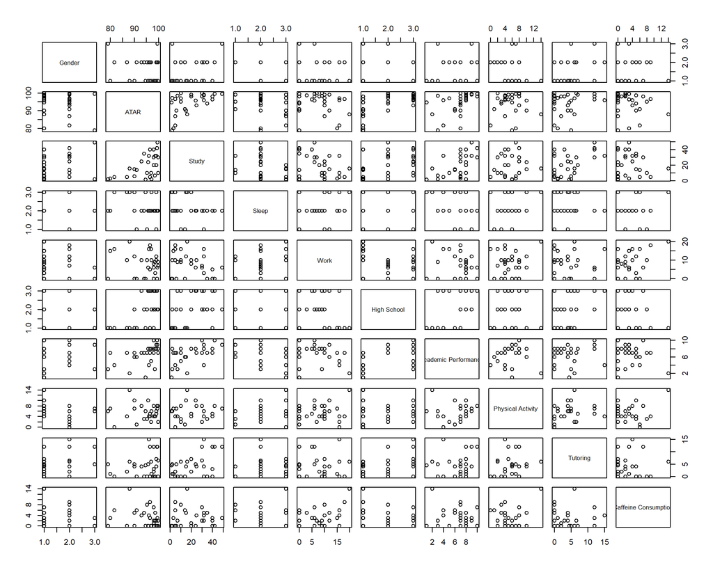

```r
pairs(surv_data[c(2:11)])
```

## Research Questions

### Q, What impact does study time have on a student’s academic performance?

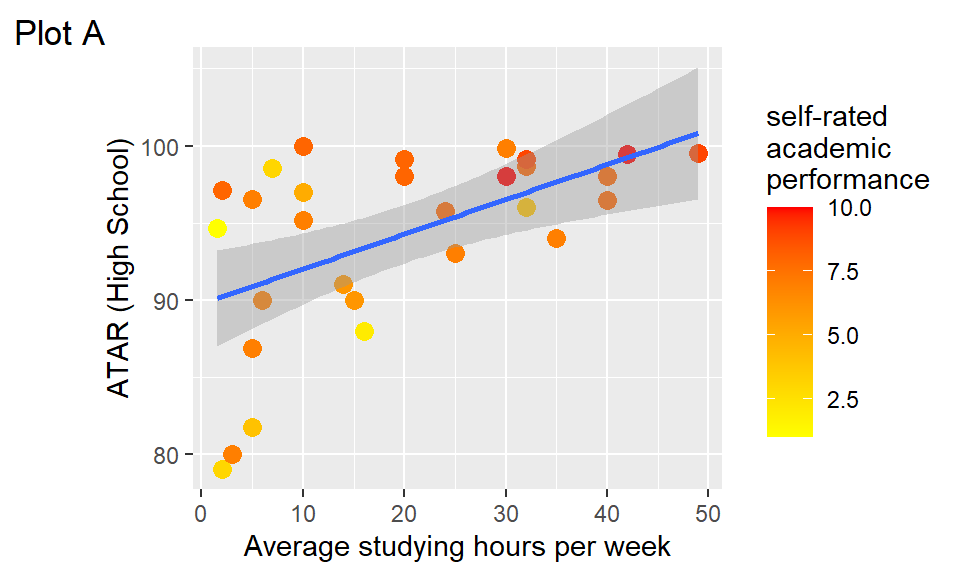

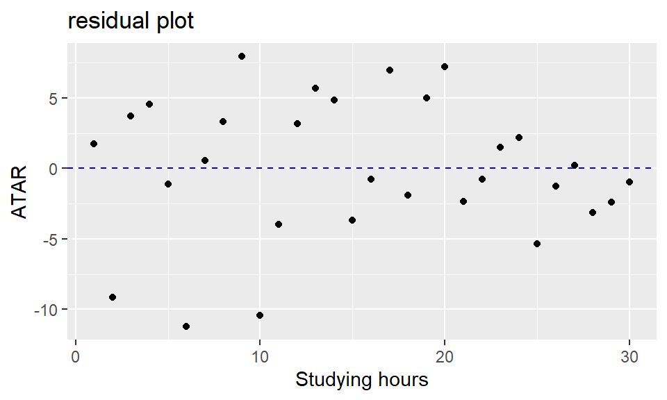

```r
`self-rated\nacademic\nperformance` <- surv_data$`Academic Performance`
ggplot(surv_data, aes(x=Study, y=ATAR)) +
  geom_point(aes(color=`self-rated\nacademic\nperformance` ), size=3) + geom_smooth(method = "lm") +
  labs(x="Average studying hours per week", y="ATAR (High School)", tag="Plot A") +
   scale_colour_gradient(low = "yellow", high = "red")

rs_data <- augment(lm(ATAR~ Study, data = surv_data))
ggplot(rs_data , aes(x= 1:nrow(rs_data), y=.resid)) +
  geom_point() +
  geom_hline(yintercept=0, linetype="dashed", color="Blue") +
  labs(x="Studying hours", y="ATAR", title="residual plot")

cor_coef <- round(cor(x=surv_data$Study, y=surv_data$ATAR, method="pearson"), 5)
```

Pearson’s Correlation Value : 0.55074

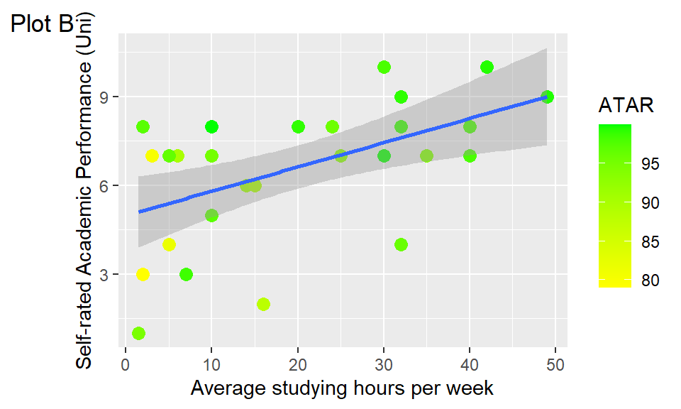

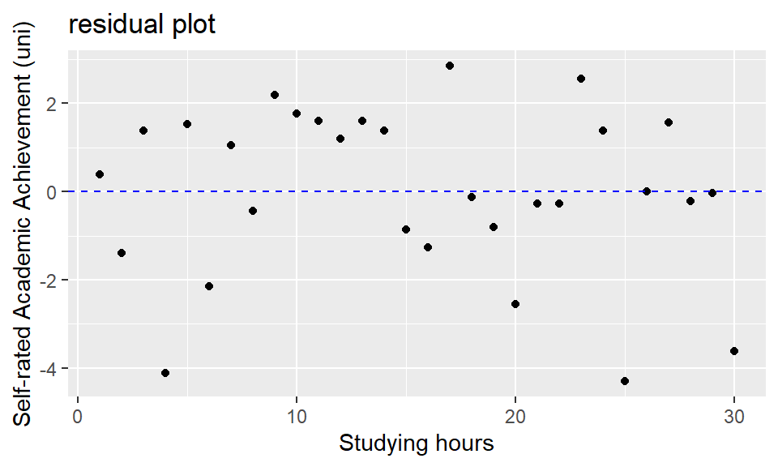

```r
ggplot(surv_data, aes(x=Study, y=`Academic Performance`)) +
  geom_point(aes(color=ATAR), size=3) + geom_smooth(method="lm") +
  labs(x="Average studying hours per week", y="Self-rated Academic Performance (Uni)", tag="Plot B") +
  scale_colour_gradient(low = "yellow", high = "green")

rs_data <- augment(lm(`Academic Performance` ~ Study, data = surv_data))
ggplot(rs_data , aes(x= 1:nrow(rs_data), y=.resid)) +
  geom_point() +
  geom_hline(yintercept=0, linetype="dashed", color="Blue") +
  labs(x="Studying hours", y="Self-rated Academic Achievement (uni)", title="residual plot")

cor_coef <- round(cor(x=surv_data$Study, y=surv_data$`Academic Performance`, method="pearson"), 5)
```

Pearson’s Correlation Value : 0.52927

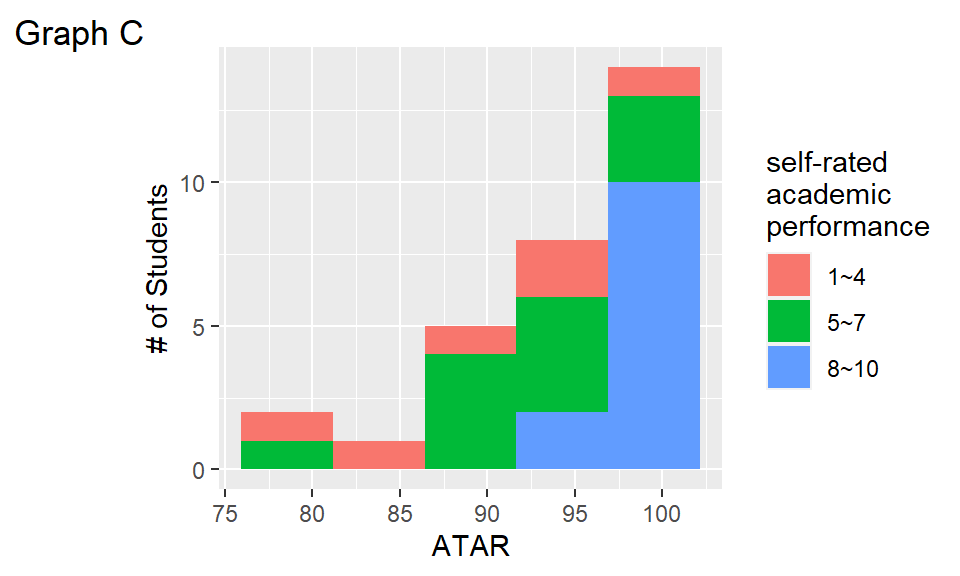

```r
ac <- surv_data$`Academic Performance`
divided_ac <- c()
for (i in 1:length(ac)){
  if (ac[i] > 0 & ac[i] <= 4){
    divided_ac <- append(divided_ac, "1~4")
  }
  else if (ac[i] > 4 & ac[i] <= 7){
    divided_ac <- append(divided_ac, "5~7")
  }
  else{
    divided_ac <- append(divided_ac, "8~10")
  }
}
`self-rated\nacademic\nperformance` <- divided_ac
ggplot(surv_data, aes(x=ATAR)) +
  geom_histogram(aes(fill=`self-rated\nacademic\nperformance`), bins=5) +
  labs(x="ATAR", y="# of Students", tag="Graph C")
```

According to the bar graph C, students with better ATAR scores tend to have a more generous and confident view of their own academic performance in university.

### Q. What impact does the environment have on a student’s grade?

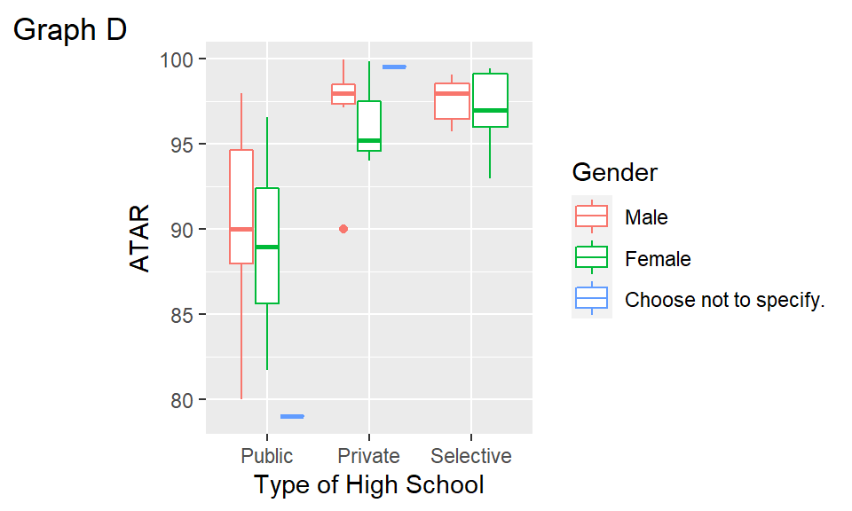

```r
ggplot(surv_data, aes(x=`High School`, y=ATAR, color=Gender)) +
  geom_boxplot() +
  labs(x="Type of High School", y="ATAR", tag="Graph D")
```

```r
sel_med <- median(surv_data$ATAR[surv_data$`High School` == "Selective"])
priv_med <- median(surv_data$ATAR[surv_data$`High School` == "Private"])
pub_med <- median(surv_data$ATAR[surv_data$`High School` == "Public"])
```

Private school students had the highest median ATAR of 98, followed by selective school students with 97.5, and then public school students with 89 In comparison to public schools, both selective and private schools have a much higher median. This could indicate that students in public schools are subjected to lower educational standards.

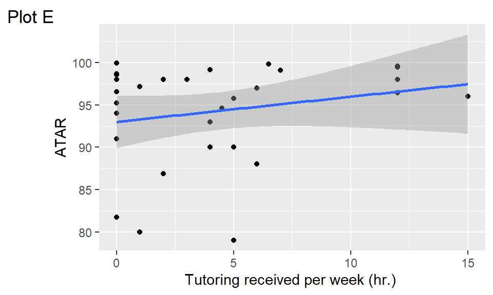

```r
ggplot(surv_data, aes(x=Tutoring, y=ATAR)) +
  geom_point() + geom_smooth(method="lm") +
  labs(x="Tutoring received per week (hr.) ", y="ATAR", tag="Plot E")
```

```r
cor_coef <- round(cor(x=surv_data$Tutoring, y=surv_data$`ATAR`, method="pearson"), 5)
```

Plot E shows that, while intensive tutoring may have a marginally positive impact on a student’s grade, the majority of students received sufficient ATAR scores with no or only a few hours of tutoring. With a pearson’s correlation value of only 0.22179, the linear link is too weak.

### Q. What effect does daily routine have on a student’s grade?

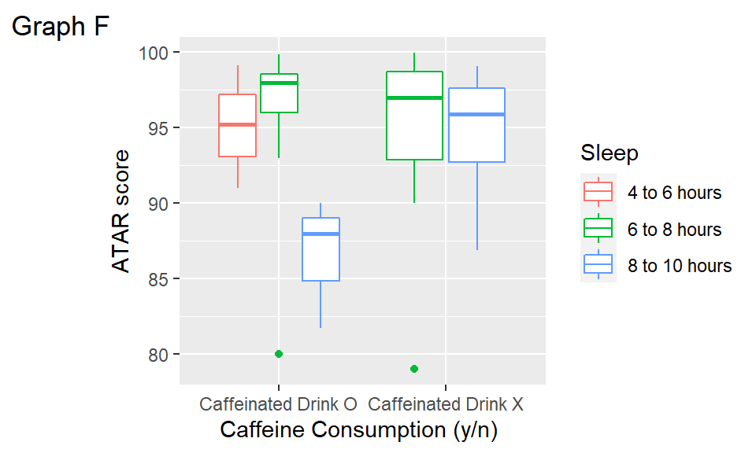

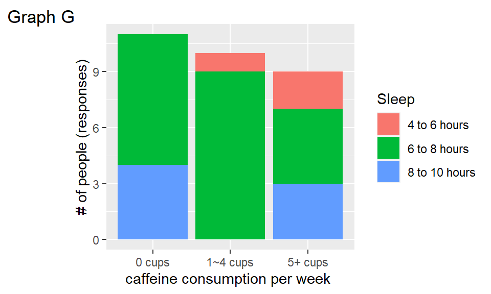

```r
c <- surv_data$`Caffeine Consumption`
drink_or_not <- c()
for (i in 1:length(c)){
  if (c[i] > 0 ){
    drink_or_not <- append(drink_or_not, "Caffeinated Drink O")
  }
  else{
    drink_or_not <- append(drink_or_not, "Caffeinated Drink X")
  }
}
names(surv_data$`Caffeine Consumption`) <- drink_or_not

ggplot(surv_data, aes(x=names(`Caffeine Consumption`), y=ATAR)) +
  geom_boxplot(aes(color=Sleep)) +
  labs(x="Caffeine Consumption (y/n) ", y="ATAR score", tag="Graph F")

divided_caffeine <- c()
for (i in 1:length(c)){
  if (c[i] == 0 ){
    divided_caffeine <- append(divided_caffeine, "0 cups")
  }
  else if (c[i] > 0 & c[i] <= 4){
    divided_caffeine <- append(divided_caffeine, "1~4 cups")
  }
  else{
    divided_caffeine <- append(divided_caffeine, "5+ cups")
  }
}
names(surv_data$`Caffeine Consumption`) <- divided_caffeine

ggplot(surv_data, aes(x=names(`Caffeine Consumption`), fill=Sleep)) +
  geom_bar() +
  labs(x="caffeine consumption per week ", y="# of people (responses)", tag="Graph G")
```

Graph F shows that the median ATAR of students who had around 6-8 hours of sleep was shown to be higher. This analysis, however, has limits because the majority of survey respondents said they sleep for an average of 6 to 8 hours.

Both graphs F and G imply that increasing caffeine consumption could raise the likelihood of sleep deprivation, assuming that getting just 4 to 6 hours of sleep per day is bad for health.

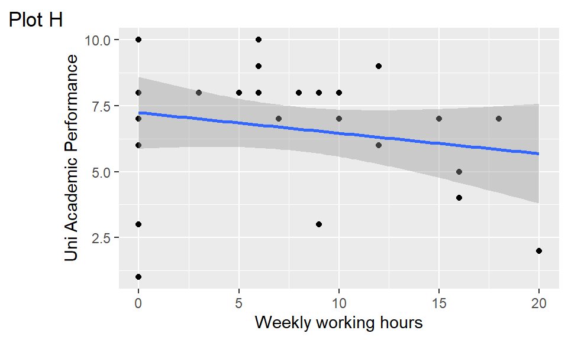

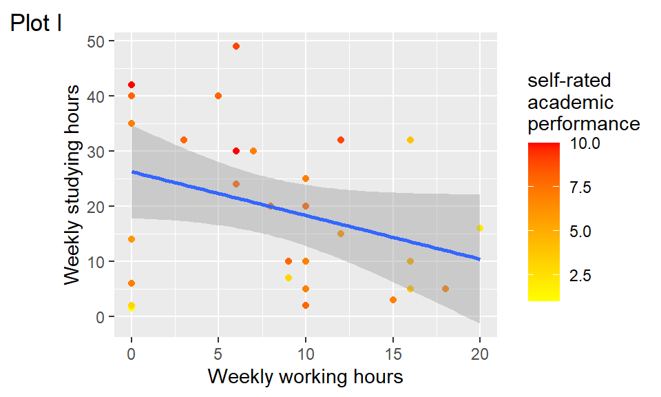

```r
ggplot(surv_data, aes(x=Work, y=`Academic Performance`)) +
  geom_point() + geom_smooth(method="lm") +
  labs(x="Weekly working hours", y="Uni Academic Performance", tag="Plot H")

`self-rated\nacademic\nperformance` <- surv_data$`Academic Performance`
ggplot(surv_data, aes(x=Work, y=Study)) +
  geom_point(aes(color=`self-rated\nacademic\nperformance`)) + geom_smooth(method="lm") +
  scale_colour_gradient(low = "yellow", high = "red") +
  labs(x="Weekly working hours", y="Weekly studying hours", tag="Plot I")
```

Plot H appears to imply that the more work a student undertakes, the more difficult it is to get better academic results. The most obvious reason for this, we feel, stems from our discovery during the IDA that working hours are inversely proportionate to studying hours. (Plot I)

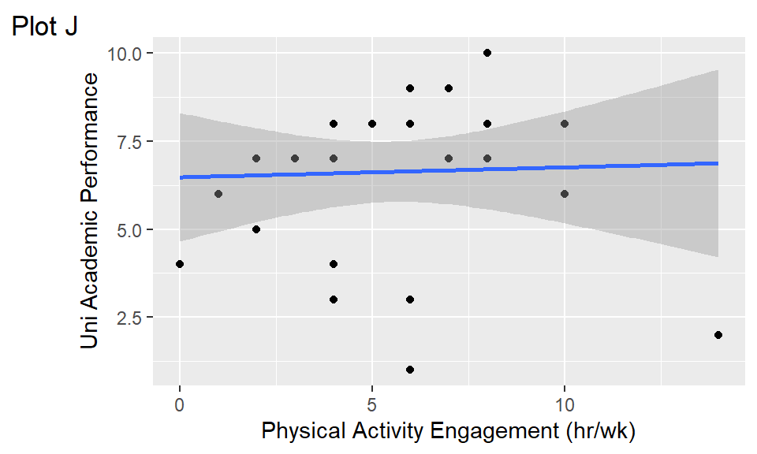

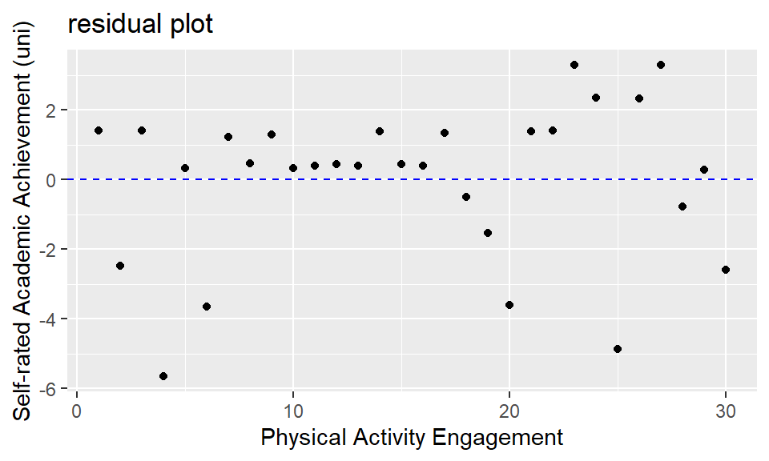

```r
ggplot(surv_data, aes(x=`Physical Activity`, y=`Academic Performance`)) +
  geom_point() + geom_smooth(method="lm") +
  labs(x="Physical Activity Engagement (hr/wk)", y="Uni Academic Performance", tag="Plot J")

rs_data <- augment(lm(`Academic Performance` ~ `Physical Activity`, data = surv_data))
ggplot(rs_data , aes(x= 1:nrow(rs_data), y=.resid)) +
  geom_point() +
  geom_hline(yintercept=0, linetype="dashed", color="Blue") +
  labs(x="Physical Activity Engagement", y="Self-rated Academic Achievement (uni)", title="residual plot")

cor_coef <- round(cor(x=surv_data$`Physical Activity`, y=surv_data$`Academic Performance`, method="pearson"), 5)
```

Pearson’s Correlation Value : 0.03711

Plot J illustrates no clear relationship between average hours engaged in physical activity per week and Academic Performance of a student.

*More limitations (biases) that need to be considered for Further Analysis:*

- **Social Desirability bias**: Respondents answer questions untruthfully in order to avoid >eing judged negatively.
- **Selection bias**: Respondents are chosen from a pool of people who are enrolled in tertiary education and have ATAR scores of range [79, 99.95]. As a result, the study may have low external validity because the sample is not a representative sample of the wider population.
- **Question order bias:** Data may be affected by “priming” due to participants answering specific questions such that general questions are internally consistent

## Articles

Article A claims that sleep problems could negatively influence students’ academic performance, and that coffee intake is one of the most deciding factors for quality sleep. (Forquer and colleagues, 2008)

Article B combines data to look at the differences in academic accomplishment between public and private schools. The findings confirm that private and selective school students have higher median ATARs. (2007, Dronkers & Robert)

## References

**Article A**  
Forquer, L., Camden, A., Gabriau, K., & Johnson, C. (2008). Sleep Patterns of College Students at a Public University. Journal Of American College Health, 56(5), 563-565. https://doi.org/10.3200/jach.56.5.563-565

**Article B**  
Dronkers, J., & Robert, P. (2007). Differences in Scholastic Achievement of Public, Private Government-Dependent, and Private Independent Schools. Educational Policy, 22(4), 541-577. https://doi.org/10.1177/0895904807307065

**Github Page**  
https://github.com/yonghyeon0223/DATA1001.git

## Acknowledgments

### Group meetings

From week 3 through week 7, we held group sessions at Carslaw Learning Hub on Thursdays from 6 to 7 p.m. (after our in-person tutorial).

### Group Roles: (contribution)

- **Isaac(510603294):** Compilation of the R Markdown Project Report, including data wrangling, IDA & producing most numerical summaries and data visualizations. Analysis on Graph F, G, H, I. Presentation(video)
- **Jiayu(520438936):** Analysis of data visualizations: Graph C, E, Produced linear modeling and residual plots. Background Research on Correlation between caffeine consumption and academic achievement. Presentation(video)
- **Rachiwon(520512915):** Researched about potential biases in our research. Analysis of Graph D.
- **Andrea(520450156):** Analysis of Graph A and B. Responsible for creating video script and editing. Presentation(video)
- **Sacha(510513719):** Topic Selection, Meeting Facilitator, Carried out most IDA. Wrote Acknowledgement section. Presentation(video)
- **Everyone:** Design survey questions. Discussions on the limitations of our research.